# Master’s Final Work

Joel A. Mensah

2022-10-12

```r
install.packages("ChainLadder")
library(ChainLadder)
```

*loading incremental claims paid into R*

```r
n <- 5
Claims <- data.frame(originf = factor(rep(2017:2021, n:1)),
                     dev=sequence(n:1),
                     inc.paid=
                       c(13956486,7174214,1416436,0,0,
                         14969138,10133536,0,0,
                         16152486,8316985,0,
                         19647454,13286230,
                         10098927))
```

*To present the data in a triangle format, we can use the matrix function:*

```r
(inc.triangle <- with(Claims, {
  M <- matrix(nrow=n, ncol=n,
              dimnames=list(origin=levels(originf), dev=1:n))
  M[cbind(originf, dev)] <- inc.paid
  M}))
```

```
##       dev
## origin        1        2       3  4  5
##   2017 13956486  7174214 1416436  0  0
##   2018 14969138 10133536       0  0 NA
##   2019 16152486  8316985       0 NA NA
##   2020 19647454 13286230      NA NA NA
##   2021 10098927       NA      NA NA NA
```

*getting the cummulative claims paid*

```r
(cum.triangle <- t(apply(inc.triangle, 1, cumsum)))
```

```
##       dev
## origin        1        2        3        4        5
##   2017 13956486 21130700 22547136 22547136 22547136
##   2018 14969138 25102674 25102674 25102674       NA
##   2019 16152486 24469471 24469471       NA       NA
##   2020 19647454 32933684       NA       NA       NA
##   2021 10098927       NA       NA       NA       NA
```

*The latest diagonal of the triangle presents the latest cumulative paid position of all origin years:*

```r
(latest.paid <- cum.triangle[row(cum.triangle) == n - col(cum.triangle) + 1])
```

```
## [1] 10098927 32933684 24469471 25102674 22547136
```

*sum of latest diagonal of the triangle*

```r
sum(latest.paid <- cum.triangle[row(cum.triangle) == n - col(cum.triangle) + 1])
```

```
## [1] 115151892
```

*We add the cumulative paid data as a column to the data frame as well*

```r
Claims$cum.paid <- cum.triangle[with(Claims, cbind(originf, dev))]
```

*To start the reserving analysis, we plot the data:*

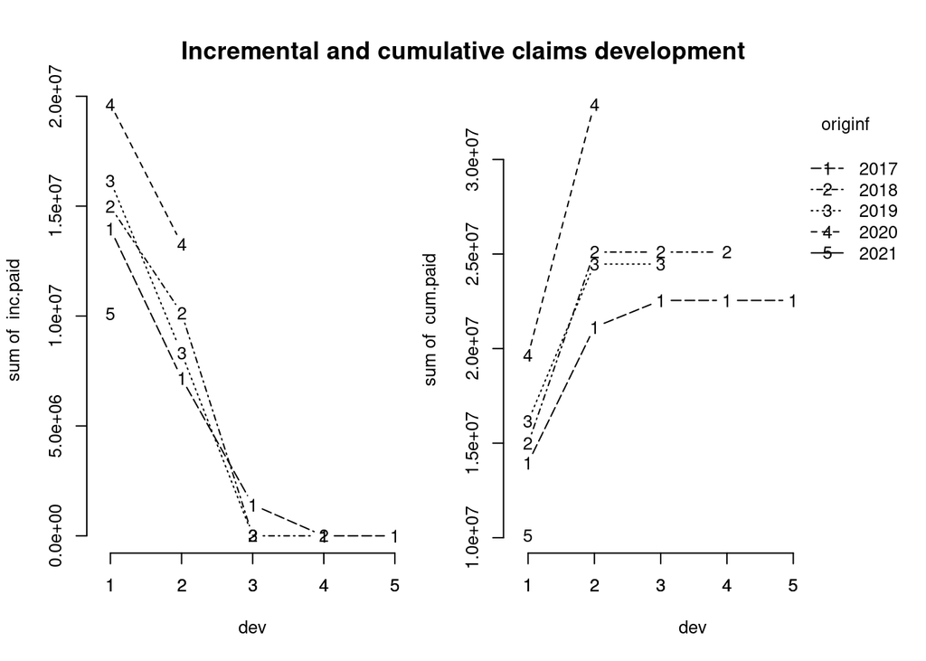

```r
op <- par(fig=c(0,0.5,0,1), cex=0.8, oma=c(0,0,0,0))
with(Claims, {
  interaction.plot(x.factor=dev, trace.factor=originf, response=inc.paid,
                   fun=sum, type="b", bty='n', legend=FALSE); axis(1, at=1:n)
  par(fig=c(0.45,1,0,1), new=TRUE, cex=0.8, oma=c(0,0,0,0))
  interaction.plot(x.factor=dev, trace.factor=originf, response=cum.paid,
                   fun=sum, type="b", bty='n'); axis(1,at=1:n)
})
mtext("Incremental and cumulative claims development",
      side=3, outer=TRUE, line=-3, cex = 1.1, font=2)
```

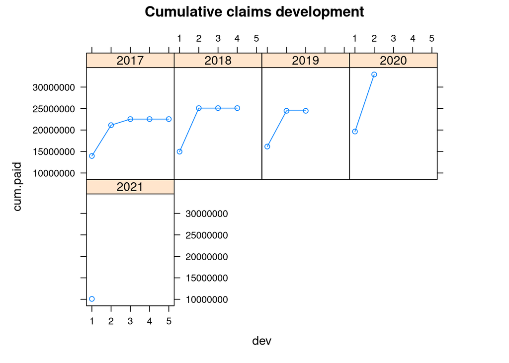

```r
par(op)
library(lattice)
xyplot(cum.paid ~ dev | originf, data=Claims, t="b", layout=c(4,2),
       as.table=TRUE, main="Cumulative claims development")
```

*Most commonly as a first step, the age-to-age link ratios fk are calculated as the volume weighted average development ratios of a cumulative loss development triangle from one age* *period to the next*

```r
f <- sapply((n-1):1, function(i) {
  sum( cum.triangle[1:i, n-i+1] ) / sum( cum.triangle[1:i, n-i] )
})
```

*Initially we expect no further development after year 5. Hence, we set the last link ratio (often called the tail factor) to 1:*

```r
tail <- 1
(f <- c(f, tail))
```

```
## [1] 1.601168 1.020034 1.000000 1.000000 1.000000
```

*These factors fk are then applied to the latest cumulative payment in each row (Ci,n−i+1) to produce stepwise forecasts for future payment years.The squaring of the claims triangle is* *calculated below:*

```r
full.triangle <- cum.triangle
for(k in 1:(n-1)){
  full.triangle[(n-k+1):n, k+1] <- full.triangle[(n-k+1):n,k]*f[k]
}
full.triangle
```

```
##       dev
## origin        1        2        3        4        5
##   2017 13956486 21130700 22547136 22547136 22547136
##   2018 14969138 25102674 25102674 25102674 25102674
##   2019 16152486 24469471 24469471 24469471 24469471
##   2020 19647454 32933684 33593466 33593466 33593466
##   2021 10098927 16170083 16494029 16494029 16494029
```

*The last column contains the forecast ultimate loss cost:*

```r
(ultimate.paid <- full.triangle[,n])
```

```
##     2017     2018     2019     2020     2021
## 22547136 25102674 24469471 33593466 16494029
```

*The cumulative products of the age-to-age development ratios provide the loss development factors for the latest cumulative paid claims for each row to ultimate*

```r
(ldf <- rev(cumprod(rev(f))))
```

```
## [1] 1.633246 1.020034 1.000000 1.000000 1.000000
```

*The inverse of the loss development factor estimates the proportion of claims developed to date for each origin year, often also called the gross up factors or growth curve:*

```r
(dev.pattern <- 1/ldf)
```

```
## [1] 0.6122778 0.9803598 1.0000000 1.0000000 1.0000000
```

*The total estimated outstanding loss reserve with this method is*

```r
sum(ultimate.paid - latest.paid)
```

```
## [1] 7054884
```

*The Mack Model*

```r
(mack <- MackChainLadder(cum.triangle, weights=1, alpha=1,
                         est.sigma="Mack"))
```

```
## MackChainLadder(Triangle = cum.triangle, weights = 1, alpha = 1,
##     est.sigma = "Mack")
##
##          Latest Dev.To.Date   Ultimate     IBNR Mack.S.E CV(IBNR)
## 2017 22,547,136       1.000 22,547,136 0.00e+00 0.00e+00      NaN
## 2018 25,102,674       1.000 25,102,674 0.00e+00 3.30e-23      Inf
## 2019 24,469,471       1.000 24,469,471 3.73e-09 5.53e-09    1.486
## 2020 32,933,684       0.980 33,593,466 6.60e+05 1.27e+06    1.921
## 2021 10,098,927       0.612 16,494,029 6.40e+06 1.54e+06    0.241
##
##                   Totals
## Latest:   115,151,892.00
## Dev:                0.94
## Ultimate: 122,206,775.63
## IBNR:       7,054,883.63
## Mack.S.E    2,116,988.64
## CV(IBNR):           0.30
```

*Plot of the actual and expected cumulative claims development and estimated standard error of the Mack model forecast*

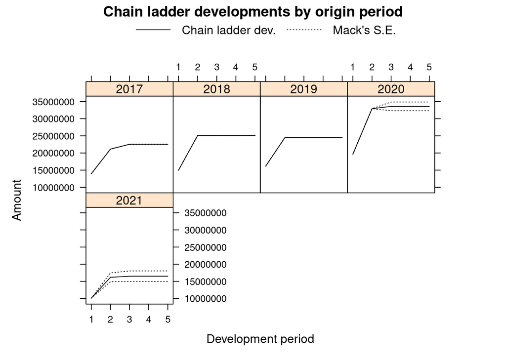

```r
plot(mack, lattice=TRUE, layout=c(4,2))
```

*Plot of MackChainLadder output*

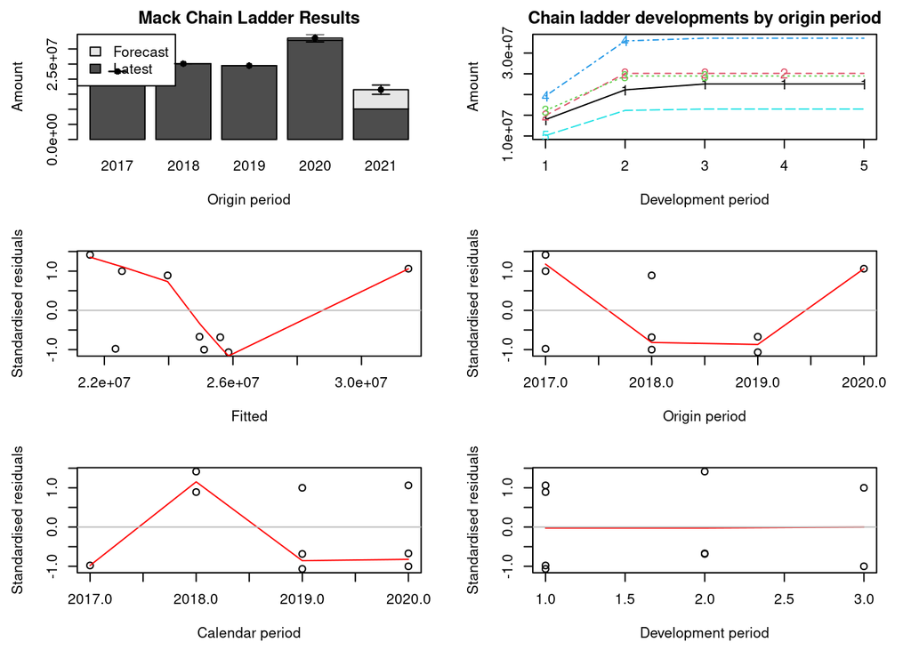

```r
plot(mack)
```

```r
install.packages("dplyr")
install.packages("readxl")
install.packages("pivottabler")
install.packages("boot")
library(dplyr)
library(readxl)
library(pivottabler)
library(boot)
```

*reading the Dataset into R*

```r
claimdata = readxl::read_xlsx("./Glm_loss_reserving_20220823.xlsx")
```

*chain ladder with risk group*

```r
model1 = glm(formula=paid ~ factor(risk_group) + factor(year_development)+factor(year_accident),
             family=quasi(variance = "mu", link = "log"),
             offset=log(exposure),
             weights=weight,
             data=claimdata)
summary(model1)
```

```
##
## Call:
## glm(formula = paid ~ factor(risk_group) + factor(year_development) +
##     factor(year_accident), family = quasi(variance = "mu", link = "log"),
##     data = claimdata, weights = weight, offset = log(exposure))
##
## Deviance Residuals:
##     Min       1Q   Median       3Q      Max
## -1119.2   -182.7      0.0      0.0   3136.4
##
## Coefficients:
##                             Estimate Std. Error t value Pr(>|t|)
## (Intercept)                8.976e+00  1.814e-01  49.489  < 2e-16 ***
## factor(risk_group)1       -4.715e-01  1.486e-01  -3.173  0.00158 **
## factor(year_development)1 -5.089e-01  1.553e-01  -3.276  0.00111 **
## factor(year_development)2 -3.440e+00  6.523e-01  -5.273 1.85e-07 ***
## factor(year_development)3 -2.373e+01  1.223e+04  -0.002  0.99845
## factor(year_development)4 -2.368e+01  1.731e+04  -0.001  0.99891
## factor(year_accident)2018  1.088e-01  2.222e-01   0.490  0.62457
## factor(year_accident)2019  5.611e-02  2.236e-01   0.251  0.80190
## factor(year_accident)2020  3.422e-01  2.098e-01   1.631  0.10339
## factor(year_accident)2021 -3.254e-01  2.962e-01  -1.099  0.27235
## ---
## Signif. codes:  0 '***' 0.001 '**' 0.01 '*' 0.05 '.' 0.1 ' ' 1
##
## (Dispersion parameter for quasi family taken to be 586278.3)
##
##     Null deviance: 265646952  on 629  degrees of freedom
## Residual deviance: 145652733  on 620  degrees of freedom
## AIC: NA
##
## Number of Fisher Scoring iterations: 9
```

```r
model1_predictions = predict(model1, type="response")
model1_residuals = residuals(model1, type="response")
```

*We add the predictions, residuals, outstanding to the data*

```r
claimdata$preds <- model1_predictions
claimdata$residuals <- model1_residuals
claimdata$outstanding <- claimdata$preds*(claimdata$year_calendar>2021)
```

*We build pivot tables with observations, predictions and total outstanding*

```r
qhpvt(claimdata, "risk_group", "year_development", "sum(round(paid,0))")
```

[interactive chart not shown]

```r
qhpvt(claimdata, "risk_group", "year_development", "sum(round(outstanding,0))")
```

[interactive chart not shown]

```r
qhpvt(claimdata, "year_accident", "risk_group", "sum(round(preds,0))")
```

[interactive chart not shown]

*chain ladder without risk group*

```r
model2 = glm(formula=paid ~ factor(year_development) + factor(year_accident),
             family=quasi(variance = "mu", link = "log"),
             offset=log(exposure),
             weights=weight,
             data=claimdata)
model2_predictions = predict(model2, type="response")
model2_residuals = residuals(model2, type="response")
summary(model2)
```

```
##
## Call:
## glm(formula = paid ~ factor(year_development) + factor(year_accident),
##     family = quasi(variance = "mu", link = "log"), data = claimdata,
##     weights = weight, offset = log(exposure))
##
## Deviance Residuals:
##     Min       1Q   Median       3Q      Max
## -1177.6   -163.2      0.0      0.0   3304.6
##
## Coefficients:
##                             Estimate Std. Error t value Pr(>|t|)
## (Intercept)                8.766e+00  1.847e-01  47.472  < 2e-16 ***
## factor(year_development)1 -5.089e-01  1.668e-01  -3.051  0.00238 **
## factor(year_development)2 -3.440e+00  7.003e-01  -4.911 1.16e-06 ***
## factor(year_development)3 -2.375e+01  1.326e+04  -0.002  0.99857
## factor(year_development)4 -2.369e+01  1.872e+04  -0.001  0.99899
## factor(year_accident)2018  1.148e-01  2.386e-01   0.481  0.63049
## factor(year_accident)2019  7.073e-02  2.400e-01   0.295  0.76834
## factor(year_accident)2020  3.627e-01  2.252e-01   1.611  0.10776
## factor(year_accident)2021 -2.939e-01  3.179e-01  -0.924  0.35563
## ---
## Signif. codes:  0 '***' 0.001 '**' 0.01 '*' 0.05 '.' 0.1 ' ' 1
##
## (Dispersion parameter for quasi family taken to be 676142)
##
##     Null deviance: 265646952  on 629  degrees of freedom
## Residual deviance: 151764940  on 621  degrees of freedom
## AIC: NA
##
## Number of Fisher Scoring iterations: 9
```

*We add the predictions, residuals, outstanding to the data*

```r
claimdata$preds <- model2_predictions
claimdata$residuals <- model2_residuals
claimdata$outstanding <- claimdata$preds*(claimdata$year_calendar > 2021)
```

*We build pivot tables with observations, predictions and total outstanding*

```r
qhpvt(claimdata, "year_accident", "year_development", "sum(round(paid,0))")
```

[interactive chart not shown]

```r
qhpvt(claimdata, "year_accident", "year_development", "sum(round(outstanding,0))")
```

[interactive chart not shown]

```r
qhpvt(claimdata, "year_accident", "risk_group", "sum(round(preds,0))")
```

[interactive chart not shown]

*Bornhuetter-Ferguson without risk group*

```r
model4 = glm(formula=paid ~ factor(year_development),
             family=quasi(variance = "mu", link = "log"),
             offset=log(exposure),
             weights=weight,
             data=claimdata)
model4_predictions = predict(model4, type="response")
model4_residuals = residuals(model4, type="response")
summary(model4)
```

```
##
## Call:
## glm(formula = paid ~ factor(year_development), family = quasi(variance = "mu",
##     link = "log"), data = claimdata, weights = weight, offset = log(exposure))
##
## Deviance Residuals:
##     Min       1Q   Median       3Q      Max
## -1287.0   -166.7      0.0      0.0   3277.1
##
## Coefficients:
##                             Estimate Std. Error t value Pr(>|t|)
## (Intercept)                8.842e+00  9.425e-02  93.814  < 2e-16 ***
## factor(year_development)1 -4.364e-01  1.611e-01  -2.708  0.00695 **
## factor(year_development)2 -3.453e+00  6.913e-01  -4.995 7.65e-07 ***
## factor(year_development)3 -2.377e+01  1.319e+04  -0.002  0.99856
## factor(year_development)4 -2.377e+01  1.856e+04  -0.001  0.99898
## ---
## Signif. codes:  0 '***' 0.001 '**' 0.01 '*' 0.05 '.' 0.1 ' ' 1
##
## (Dispersion parameter for quasi family taken to be 664711.3)
##
##     Null deviance: 265646952  on 629  degrees of freedom
## Residual deviance: 155769608  on 625  degrees of freedom
## AIC: NA
##
## Number of Fisher Scoring iterations: 9
```

*We add the predictions, residuals, outstanding to the data*

```r
claimdata$preds <- model4_predictions
claimdata$residuals <- model4_residuals
claimdata$outstanding <- claimdata$preds*(claimdata$year_calendar > 2021)
```

*We build pivot tables with observations, predictions and total outstanding*

```r
qhpvt(claimdata, "year_accident", "year_development", "sum(round(paid,0))")
```

[interactive chart not shown]

```r
qhpvt(claimdata, "year_accident", "year_development", "sum(round(outstanding,0))")
```

[interactive chart not shown]

```r
qhpvt(claimdata, "year_accident", "risk_group", "sum(round(preds,0))")
```

[interactive chart not shown]

*Bornhuetter-Ferguson with risk group*

```r
model5 = glm(formula=paid ~ factor(risk_group)+factor(year_development),
             family=quasi(variance = "mu", link = "log"),
             offset=log(exposure),
             weights=weight,
             data=claimdata)
summary(model5)
```

```
##
## Call:
## glm(formula = paid ~ factor(risk_group) + factor(year_development),
##     family = quasi(variance = "mu", link = "log"), data = claimdata,
##     weights = weight, offset = log(exposure))
##
## Deviance Residuals:
##     Min       1Q   Median       3Q      Max
## -1163.8   -186.8      0.0      0.0   3111.7
##
## Coefficients:
##                             Estimate Std. Error t value Pr(>|t|)
## (Intercept)                   9.0377     0.1028  87.923  < 2e-16 ***
## factor(risk_group)1          -0.4708     0.1477  -3.187  0.00151 **
## factor(year_development)1    -0.4323     0.1506  -2.871  0.00423 **
## factor(year_development)2    -3.4454     0.6460  -5.333 1.35e-07 ***
## factor(year_development)3   -23.7479 12236.8556  -0.002  0.99845
## factor(year_development)4   -23.7412 17241.5527  -0.001  0.99890
## ---
## Signif. codes:  0 '***' 0.001 '**' 0.01 '*' 0.05 '.' 0.1 ' ' 1
##
## (Dispersion parameter for quasi family taken to be 580260.8)
##
##     Null deviance: 265646952  on 629  degrees of freedom
## Residual deviance: 149666003  on 624  degrees of freedom
## AIC: NA
##
## Number of Fisher Scoring iterations: 9
```

```r
model5_predictions = predict(model5, type="response")
model5_residuals = residuals(model5, type="response")
```

*We add the predictions, residuals, outstanding to the data*

```r
claimdata$preds <- model5_predictions
claimdata$residuals <- model5_residuals
claimdata$outstanding <- claimdata$preds*(claimdata$year_calendar > 2021)
```

*We build pivot tables with observations, predictions and total outstanding*

```r
qhpvt(claimdata, "risk_group", "year_development", "sum(round(paid,0))")
```

[interactive chart not shown]

```r
qhpvt(claimdata, "risk_group", "year_development", "sum(round(outstanding,0))")
```

[interactive chart not shown]

```r
qhpvt(claimdata, "year_accident", "risk_group", "sum(round(preds,0))")
```

[interactive chart not shown]